# Phoenix Crime Trends

07 September, 2020

## Has crime in Phoenix increased during the COVID-19 pandemic?

I was wondering whether there has been an increase in crime in Phoenix since March 2020. So, I went to the city’s [open data site](https://www.phoenixopendata.com) and pulled the [crime data](https://www.phoenixopendata.com/dataset/crime-data/resource/0ce3411a-2fc6-4302-a33f-167f68608a20) which is updated every day.

### Getting the data.

Let’s pull the most recent data from the site.

```r
# set the url where the data are located.
url <- "https://www.phoenixopendata.com/dataset/cc08aace-9ca9-467f-b6c1-f0879ab1a358/resource/0ce3411a-2fc6-4302-a33f-167f68608a20/download/crimestat.csv"

# pull in the csv file.
crime.data <- read.csv(url, as.is = TRUE, header = TRUE)

# take a look at the data.
head(crime.data)
```

```
##        INC.NUMBER       OCCURRED.ON       OCCURRED.TO  UCR.CRIME.CATEGORY
## 1 201600000052855 11/01/2015  00:00 01/09/2016  00:00 MOTOR VEHICLE THEFT
## 2 201600000594484 11/01/2015  00:00                                  RAPE
## 3 201500002102327 11/01/2015  00:00 11/01/2015  09:00       LARCENY-THEFT
## 4 201500002101405 11/01/2015  00:00 11/01/2015  05:00 MOTOR VEHICLE THEFT
## 5 201500002102668 11/01/2015  00:00 11/01/2015  11:50 MOTOR VEHICLE THEFT
## 6 201600000527709 11/01/2015  00:00 03/22/2016  00:36       LARCENY-THEFT
##            X100.BLOCK.ADDR   ZIP        PREMISE.TYPE
## 1 N 43RD AVE & W CACTUS RD 85029 SINGLE FAMILY HOUSE
## 2        13XX E ALMERIA RD 85006 SINGLE FAMILY HOUSE
## 3           51XX N 15TH ST 85014           APARTMENT
## 4      102XX W MEDLOCK AVE 85307 SINGLE FAMILY HOUSE
## 5           69XX W WOOD ST 85043 SINGLE FAMILY HOUSE
## 6      33XX W CAMELBACK RD 85017         PARKING LOT
```

```r
tail(crime.data)
```

```
##             INC.NUMBER       OCCURRED.ON       OCCURRED.TO  UCR.CRIME.CATEGORY
## 315381 202000001443617 08/31/2020  23:00 08/31/2020  23:30  AGGRAVATED ASSAULT
## 315382 202000001440438 08/31/2020  23:12 08/31/2020  23:12  AGGRAVATED ASSAULT
## 315383 202000001440541 08/31/2020  23:42                              BURGLARY
## 315384 202000001440588 08/31/2020  23:57                    AGGRAVATED ASSAULT
## 315385 202000001447799 08/31/2020  23:59                         LARCENY-THEFT
## 315386 202000001467535 08/31/2020  23:59 09/01/2020  01:00 MOTOR VEHICLE THEFT
##            X100.BLOCK.ADDR   ZIP               PREMISE.TYPE
## 315381     136XX S 44TH ST 85044                  APARTMENT
## 315382  19XX W LARKSPUR DR 85029                    VEHICLE
## 315383 39XX E CAMELBACK RD 85018 CONVENIENCE MARKET / STORE
## 315384    92XX W THOMAS RD 85037        SINGLE FAMILY HOUSE
## 315385       48XX E RAY RD 85044                PARKING LOT
## 315386    48XX W PHELPS RD 85306                    UNKNOWN
```

```r
dim(crime.data)
```

```
## [1] 315386      7
```

The data are reported as UCR crime classifications and have geographic information (block address, zip) as well as the date and time of the incident. The `dim()` command returns 315,386 reports.

### Cleaning the data.

Now that the data are in the workspace, let’s clean up the date and the crime categories to make plotting them fairly easy. For this step, we will use the `lubridate()` package.

```r
# Load the library.
library(lubridate)

# Check the class of the data variable.
#crime.data$OCCURRED.ON

# Check for format of the occurred on date variable.
crime.data$OCCURRED.ON[1] # this is month, day, year as well as the time (hours and minutes).
```

```
## [1] "11/01/2015  00:00"
```

```r
mdy_hm(crime.data$OCCURRED.ON[1])
```

```
## [1] "2015-11-01 UTC"
```

```r
# create an object that is the time and the category.
dates.crimes <- data.frame(
  date = as.Date(mdy_hm(crime.data$OCCURRED.ON)),
  crime = crime.data$UCR.CRIME.CATEGORY,
  days.since = unclass(as.Date(mdy_hm(crime.data$OCCURRED.ON)))
  )

table(is.na(dates.crimes$date)) # 420 are missing dates.
```

```
##
##  FALSE   TRUE
## 314966    420
```

```r
table(is.na(dates.crimes$crime)) # none missing type of crime.
```

```
##
##  FALSE
## 315386
```

```r
# Let's drop those cases missing dates.
dates.crimes <- dates.crimes[is.na(dates.crimes$date) == FALSE,]
dim(crime.data)[1] - dim(dates.crimes)[1] # the number of cases you had to drop due to missing.
```

```
## [1] 420
```

```r
# The days.since object represents the number of days since 1/1/1970.
# We got this using the unclass() function. I like working with the numbers.
head(dates.crimes$days.since)
```

```
## [1] 16740 16740 16740 16740 16740 16740
```

### Plot it!

Now, we want to plot the data where the months are the x-axis and the frequency of the crimes are the y-axis. We have to set up some plot parameters first to get things looking nice.

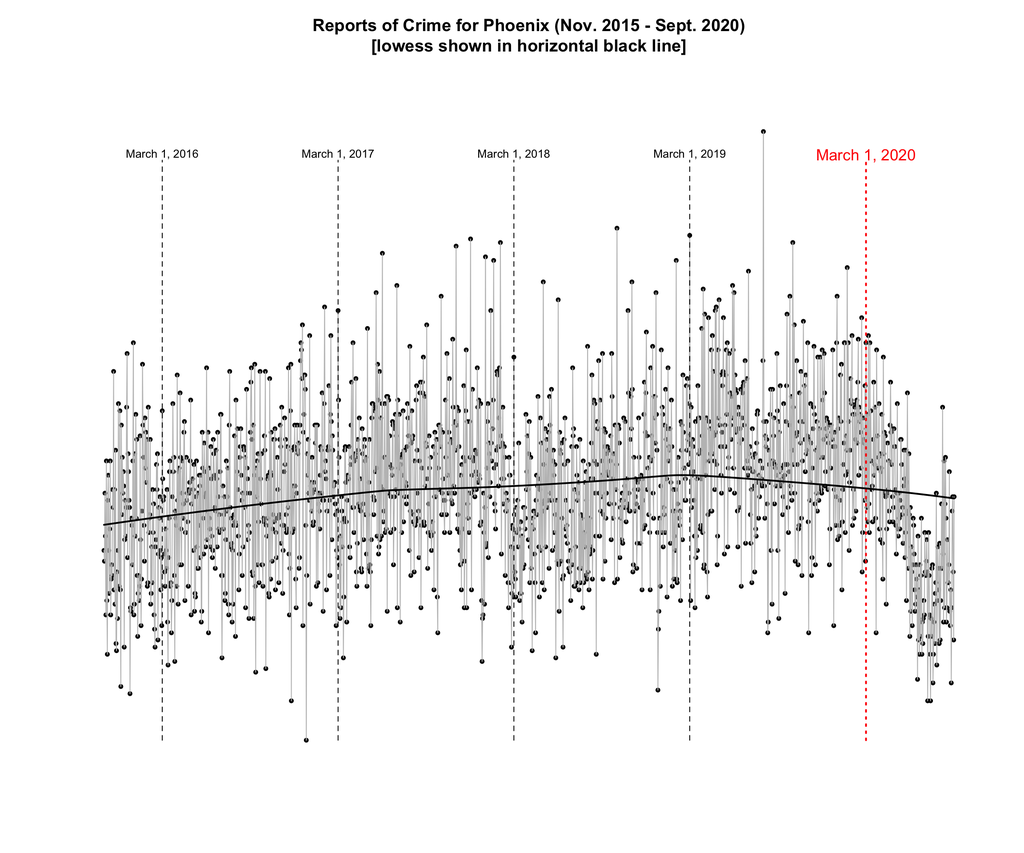

```r
# Set up the values we want to plot.
y.1 <- as.vector(table(dates.crimes$days.since - dates.crimes$days.since[1]))
x.1 <- c(seq(min(dates.crimes$days.since - dates.crimes$days.since[1]),max(dates.crimes$days.since - dates.crimes$days.since[1]),length.out = length(y.1)))

# unclass(as.Date("2020-03-01")) - dates.crimes$days.since[1] # this is March 1st 2020.
march.1.2020 <- (unclass(as.Date("2020-03-01")) - dates.crimes$days.since[1])
march.1.2019 <- (unclass(as.Date("2019-03-01")) - dates.crimes$days.since[1])
march.1.2018 <- (unclass(as.Date("2018-03-01")) - dates.crimes$days.since[1])
march.1.2017 <- (unclass(as.Date("2017-03-01")) - dates.crimes$days.since[1])
march.1.2016 <- (unclass(as.Date("2016-03-01")) - dates.crimes$days.since[1])
marches      <- cbind(march.1.2019,march.1.2018,march.1.2017,march.1.2016)

### Set plot basics and axes.
plot.new()
plot.window(xlim = c(0, max(x.1)), ylim = c(min(y.1), max(y.1)+10))

### Plot the values.
points(x = x.1, y = y.1, col = "black", pch = 16, cex = 0.75)
lines(x = x.1, y = y.1, col = "grey75", pch = 16, cex = 0.75)

# Add a segment to shown the median.
#segments(0,median(y.1),max(x.1),median(y.1), lwd = 3, lty = 3, col = "black")

# Add a line and some text for March 2020.
segments(march.1.2020, min(y.1), march.1.2020, 270,lwd = 2, lty = 3, col = "red")
text(march.1.2020, 275,"March 1, 2020", col="red", pos=1, cex=1.1)

# Add a line and some text for March in the prior years.
for(i in 1:length(marches)){
  segments(marches[i], min(y.1), marches[i], 270,lwd = 1, lty = 2, col = "black")
}
text(marches[1], 275,"March 1, 2019", col="black", pos=1, cex=0.8)
text(marches[2], 275,"March 1, 2018", col="black", pos=1, cex=0.8)
text(marches[3], 275,"March 1, 2017", col="black", pos=1, cex=0.8)
text(marches[4], 275,"March 1, 2016", col="black", pos=1, cex=0.8)

# Add a lowess line to see the trend.
lines(lowess(x.1, y.1), type = "l", col= "black", lwd = 2)

# Add a title.
title("Reports of Crime for Phoenix (Nov. 2015 - Sept. 2020)\n[lowess shown in horizontal black line]")
```

### Conclusions?

This is just a quick look, but it shows that crime went down after the pandemic hit in Phoenix. There is a brief uptick though. So, perhaps we should take a closer look at the 2020 data.